# a4_task2_Toigo_Katelyn

Katelyn Toigo

3/1/2022

### Overview

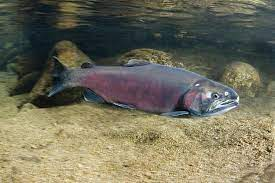

Coho salmon. Source: NOAA Fisheries

Data is provided from the Columbia River Data Access in Real Time (DART) and shows adult fish passage data from 2001-01-01 to 2010-12-31 at the Willamette Falls fish ladder on the Willamette River (Oregon). Populated variables include project, date, temperature in degrees celsius, and the number of chinook, jack chinook, steelhead, coho, and jack coho salmon. This report analyzes salmon data by looking at the time series information as a whole, by season, and by year. Coho salmon, jack coho salmon, and steelheads are assessed.

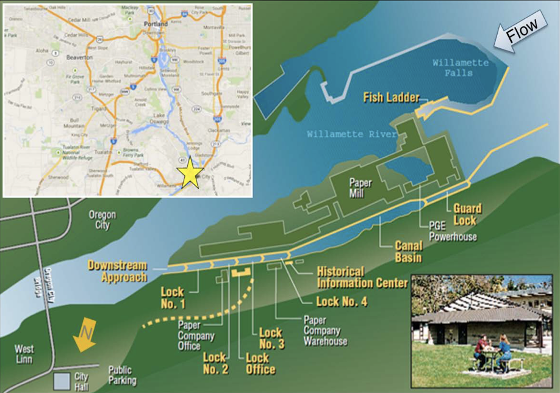

Willamette Falls map including location of fish ladder to the upper right. Source: US Army Corps of Engineers (https://media.defense.gov/2017/May/23/2001751687/-1/-1/1/DRAFT%20WFL%20INTEGRATED%20DISPOSITION%20STUDY%20AND%20EA.PDF)

**Data citation:** Columbia River Basin Data Access in Real Time (DART). DART Adult Passage Graphics and Text. Accessed on March 3, 2022. http://www.cbr.washington.edu/dart/query/adult_graph_text

```r
# Read in the data
fish <- read_csv(here("data", "willamette_fish_passage.csv")) %>%
  clean_names() %>%
  select(project, date, steelhead, coho, jack_coho, temp_c) %>%
  mutate_all(~replace(., is.na(.), 0)) %>%
  mutate(date = lubridate::mdy(date))

fish_ts <- fish %>%
  as_tsibble(key = NULL, index = date)
```

## Willamette Falls Fish Passage Time Series Summary

### Original Time Series

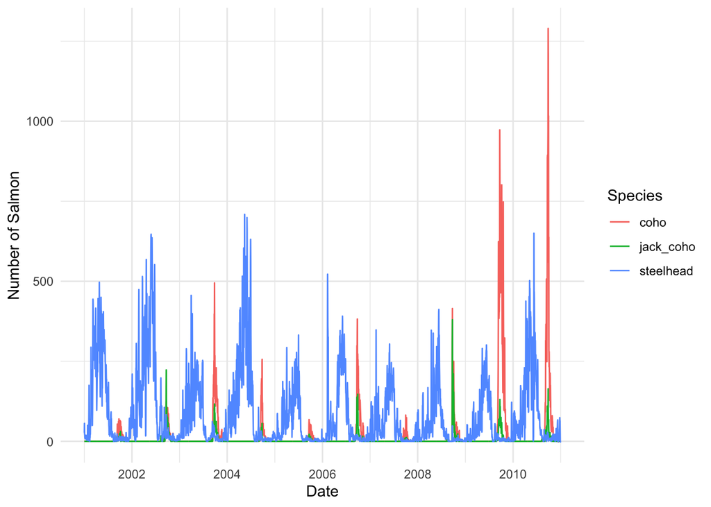

```r
fish_orig <- fish_ts %>%
    pivot_longer(cols = c(coho, jack_coho, steelhead), names_to = "species", values_to = "count")

p1 <- ggplot(data = fish_orig, aes(x = date, y = count), color = species) +
  geom_line(aes(color = species)) +
  theme_minimal() +
  labs(x = "Date",
       y = "Number of Salmon",
       col = "Species")
p1
```

**Figure 1.** Number of coho, jack coho, and steelhead salmon passing through the Willamette Falls fish ladder between January 1, 2001 and December 31, 2010.

- Steelhead passage numbers appear to have a consistent cyclical pattern throughout the entire time series.
- Coho salmon increase their passage numbers towards the end of the time series.
- Jack coho salmon are counted in fewer numbers than coho and steelhead salmon almost every year.

### Seasonplots

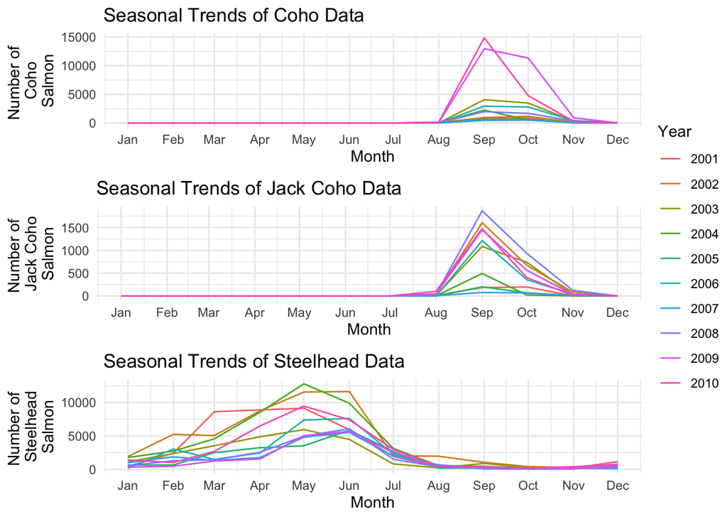

```r
# Coho
coho_month <- fish_ts %>%
  index_by(yr_mo = ~yearmonth(.)) %>% # groups by index value
  summarize(coho_month_count = sum(coho))

p4 <- coho_month %>%
  gg_season(y = coho_month_count) +
  theme_minimal() +
  ggtitle("Seasonal Trends of Coho Data") +
  labs(x = "Month",
       y = "Number of \n Coho \nSalmon",
       col = "Year")


# Jack Coho
jack_coho_month <- fish_ts %>%
  index_by(yr_mo = ~yearmonth(.)) %>% # groups by index value
  summarize(jack_coho_month_count = sum(jack_coho))

p5 <- jack_coho_month %>%
  gg_season(y = jack_coho_month_count) +
  theme_minimal() +
  ggtitle("Seasonal Trends of Jack Coho Data") +
  labs(x = "Month",
       y = "Number of \n Jack Coho \nSalmon",
       col = "Year")

# Steelhead
steelhead_month <- fish_ts %>%
  index_by(yr_mo = ~yearmonth(.)) %>% # groups by index value
  summarize(steelhead_month_count = sum(steelhead)) %>%
  mutate(year = year(yr_mo))

p6 <- steelhead_month %>%
  gg_season(y = steelhead_month_count) +
  theme_minimal() +
  ggtitle("Seasonal Trends of Steelhead Data") +
  labs(x = "Month",
       y = "Number of \n Steelhead \nSalmon",
       col = "Year")

ggarrange(p4, p5, p6, ncol = 1, common.legend = TRUE, legend = "right")
```

**Figure 2.** Seasonplot. Number of coho, jack coho, and steelhead salmon passing through the Willamette Falls fish ladder each month between January 1, 2001 and December 31, 2010.

### Annual Counts by Species

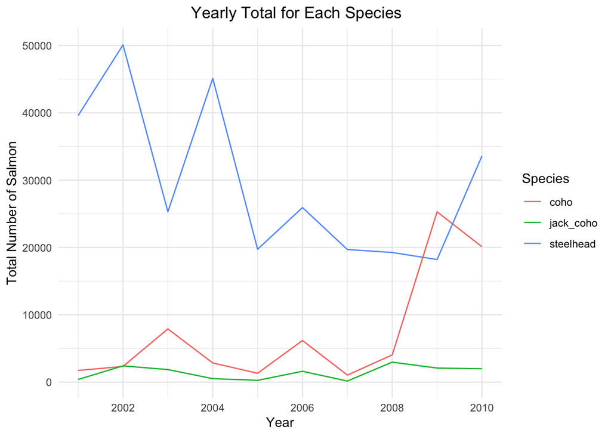

```r
fish_annual <- fish_orig %>%
  index_by(yearly = ~year(.)) %>%
  group_by(species) %>%
  summarize(total_species = sum(count))

ggplot(data = fish_annual, aes(x = yearly, y = total_species)) +
  geom_line(aes(color = species)) +
  theme_minimal()+
  ggtitle("                              Yearly Total for Each Species") +
  labs(x = "Year",
       y = "Total Number of Salmon",
       col = "Species") +
  scale_x_continuous(breaks = c(2002, 2004, 2006, 2008, 2010))
```

```r
### define manually - scale_x_disc or continuous
```

**Figure 3.** Annual total counts by species between January 1, 2001 and December 31, 2010.